# 02

2019-10-14

## tl;dr

If you conclude results from group-level data will tell you about individual-level processes, even of the individuals whose data made up those group-level data, you would be committing the *ecological fallacy*. This can be odd and counterintuitive and it might take some practice to get a hold of.

## We need history.

The ecological fallacy is closely related to Simpson’s paradox. It is often attributed to sociologist William S. Robinson’s (1950) paper [*Ecological Correlations and the Behavior of Individuals*](https://www.jstor.org/stable/2087176?origin=crossref&seq=1#page_scan_tab_contents). My fellow psychologists might be happy to learn the idea goes back at least as far as E. L. Thorndike’s (1939) paper, [*On the fallacy of imputing the correlations found for groups to the individuals or smaller groups composing them*](https://www.jstor.org/stable/1416673?seq=1#page_scan_tab_contents). Yet as far as I can tell, the term “ecological fallacy” itself first appeared in sociologist Hanan C. Selvin’s (1958) paper, *Durkheim’s suicide and problems of empirical research*.

The central point of Robinson’s paper can be summed up in this quote: “There need be no correspondence between the individual correlation and the ecological correlation” (p. 339) [^1]. Robinson framed his argument in terms of correlations. In more general and contemporary terms, his insight was that results from between-person analyses will not necessarily match up with results from within-person analyses. When we assume the results from a between-person analysis will tell us about within-person processes, we commit the ecological fallacy.

## An example might help.

Though Thorndike, Robinson, and Selvin all worked through examples of the ecological fallacy, I’m a fan of methodologist Ellen Hamaker’s example. We’ll quote from her (2012) chapter, [*Why researchers should think “within-person”: A paradigmatic rationale*](http://www.geo.uzh.ch/~screde/share/ReadingGroup/Hamaker-12.pdf), in bulk:

> Suppose we are interested in the relationship between typing speed (i.e., number of words typed per minute) and the percentage of typos that are made. If we look at the cross-sectional relationship (i.e., the population level), we may well find a negative relationship, in that people who type faster make fewer mistakes (this may be reflective of the fact that people with better developed typing skills and more experience both type faster and make fewer mistakes). (p. 44)

Based on a figure in Hamaker’s chapter, that cross-sectional relationship might look something like this.

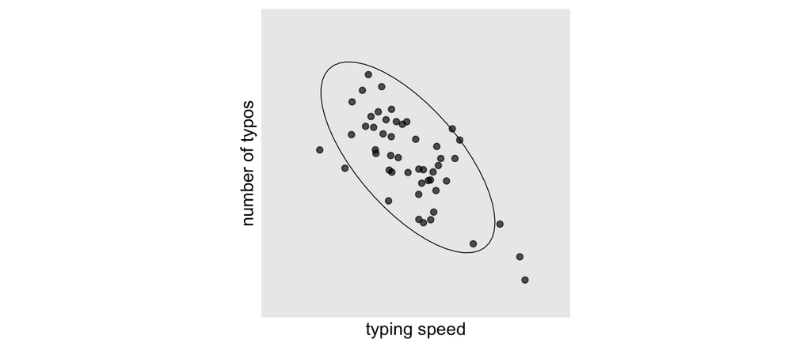

```r
library(tidyverse)

d %>%
  filter(j == 1) %>%

  ggplot(aes(x = x, y = y)) +
  geom_point(alpha = 2/3) +
  stat_ellipse(size = 1/4) +
  scale_x_continuous("typing speed", breaks = NULL, limits = c(-3, 3)) +
  scale_y_continuous("number of typos", breaks = NULL, limits = c(-3, 3)) +
  coord_equal() +
  theme(panel.grid = element_blank())
```

I’m not going to show you how I made these data just yet. It’d break up the flow. For the curious, the statistical formula and code are at the end of the post. I should point out, though, that the scale is arbitrary. Anyway, here’s the cross-sectional correlation.

```r
d %>%
  filter(j == 1) %>%
  summarise(correlation_between_participants = cor(x, y))
```

| correlation_between_participants |
| --- |
| -0.6963061 |

In the chapter, Hamaker continued her case.

> If we were to generalize this result to the within-person level, we would conclude that if a particular person types faster, he or she will make fewer mistakes. Clearly, this is not what we expect: In fact, we are fairly certain that for any particular individual, the number of typos will increase if he or she tries to type faster. This implies a positive–rather than a negative–relationship at the within-person level. (p. 44)

The simulated data I just showed were from 50 participants at one measurement occasion. However, the full data set contains 50 measurement occasions for each of the 50 participants. In the next plot, we’ll show the all 50 measurement occasions for just 5 participants. The $n$ is reduced in the plot to avoid cluttering.

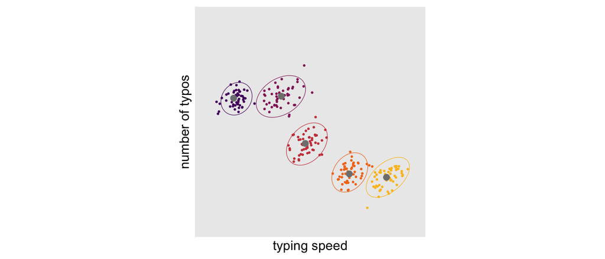

```r
d %>%
  filter(i %in% c(1, 10, 25, 47, 50)) %>%
  mutate(i = factor(i)) %>%

  ggplot() +
  geom_point(aes(x = x, y = y, color = i),
             size = 1/3) +
  stat_ellipse(aes(x = x, y = y, color = i),
               size = 1/5) +
  geom_point(data = d %>%
               filter(j == 1 &
                        i %in% c(1, 10, 25, 47, 50)),
             aes(x = x0, y = y0),
             size = 2, color = "grey50") +
  scale_color_viridis_d(option = "B", begin = .25, end = .85) +
  scale_x_continuous("typing speed", breaks = NULL, limits = c(-3, 3)) +
  scale_y_continuous("number of typos", breaks = NULL, limits = c(-3, 3)) +
  coord_equal() +
  theme(panel.grid = element_blank(),
        legend.position = "none")
```

The points are colored by participant. The gray points in each data cloud are the participant-level means. Although we still see a clear negative relationship between participants, we now also see a mild positive relationship within participants. Here is the distribution of those correlations across participants.

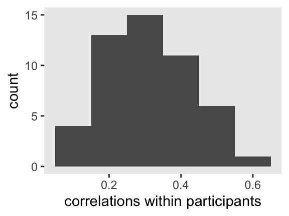

```r
d %>%
  group_by(i) %>%
  summarise(r = cor(x, y) %>% round(digits = 2)) %>%

  ggplot(aes(x = r)) +
  geom_histogram(binwidth = .1) +
  xlab("correlations within participants") +
  theme(panel.grid = element_blank())
```

Hopefully this gives you a sense of how meaningless a question like *What is the correlation between typing speed and typo rates?* is. The question is poorly specified because it makes no distinction between the between- and within-person frameworks. As it turns out, the answer could well be different depending on which one you care about and which one you end up studying. I suspect poorly-specified questions of this kind are scattered throughout the literature. For example, I’m a clinical psychologist. Have you ever heard a clinical psychologist talk about how highly anxiety is correlated with depression? And yet much of that evidence is cross-sectional (e.g., correlations between the anxiety and depression subscales of the DASS; [Lovibond & Lovibond, 1995](https://www.womenshealthapta.org/wp-content/uploads/2013/12/DASS-Lovibond.pdf)). But what about *within* specific people? Do you really believe anxiety and depression are highly-correlated in all people? More cross-sectional analyses will not answer that question.

## Take home the take-home.

Our typing data are is just one example of how between- and within-person analyses can differ. To see Hamaker walk out the example herself, check out her [talk on the subject](https://www.youtube.com/watch?v=RnbsXfE2R9g) from a few years ago. I think you’ll find her an engaging speaker. To close this topic out, it’s worth considering the Conclusion section from Robinson’s (1950) paper in full:

> The relation between ecological and individual correlations which is discussed in this paper provides a definite answer as to whether ecological correlations can validly be used as substitutes for individual correlations. They cannot. While it is theoretically possible for the two to be equal, the conditions under which this can happen are far removed from those ordinarily encountered in data. From a practical standpoint, therefore, the only reasonable assumption is that an ecological correlation is almost certainly not equal to its corresponding individual correlation.

> I am aware that this conclusion has serious consequences, and that its effect appears wholly negative because it throws serious doubt upon the validity of a number of important studies made in recent years. The purpose of this paper will have been accomplished, however, if it prevents the future computation of meaningless correlations and stimulates the study of similar problems with the use of meaningful correlations between the properties of individuals. (pp. 340–341)

## This stuff is hard.

The ecological fallacy demonstrated something similar, but from a different angle. That literature showed us that the results from a between-person analysis will not necessarily inform us of within-person processes. The converse is logically true, too. Indeed, the ecological fallacy is something of a special case of Simpson’s paradox. With the ecological fallacy, the grouping variable is participant id which, when accounted for, yields a different level of analysis [^2].

If at this point you find yourself fatigued and your head hurts a little, don’t worry. You’re probably normal. In a series of experiments, [Fiedler, Walther, Freytag, and Nickel (2003)](http://citeseerx.ist.psu.edu/viewdoc/download?doi=10.1.1.839.8878&rep=rep1&type=pdf) showed it’s quite normal to struggle with these concepts. For more practice, check out Kievit, Frankenhuis, Waldorp, and Borsboom’s nice (2013) paper, [*Simpson’s paradox in psychological science: a practical guide*](https://www.frontiersin.org/articles/10.3389/fpsyg.2013.00513). Kuppens and Pollet (2014) covered more examples of teh fallacy in their [*Mind the level: problems with two recent nation-level analyses in psychology*](https://www.frontiersin.org/articles/10.3389/fpsyg.2014.01110/full#h5). I’ve also worked out and posted the exmples in Thorndike’s (1939) paper, which you can find [here](https://github.com/ASKurz/ecological_fallacy_Thorndike/tree/master).

## Afterward: How might one simulate those typing speed data?

For simplicity, $\beta_0^x$ and $\beta_0^y$ were fixed to zero. Note I’m using the $\sigma$ parameterization instead of the $\sigma^2$ parameterization. In words, this is a bivariate intercepts-only multilevel model. For an introduction to these kinds of models, check out [Baldwin, Imel, Braithwaite, and Atkins (2014)](https://www.ncbi.nlm.nih.gov/pmc/articles/PMC4119868/).

The approach I used to generate the data is an extension of the one I used in my project recoding McElreath’s (2015) text. You can find the original code, [here](https://bookdown.org/content/1850/adventures-in-covariance.html#varying-slopes-by-construction). There are two big changes to the original. First, setting the random effects for the mean structure to a $z$-score metric simplified that part of the code quite a bit. Second, I defined the residuals, which were correlated, in a separate data object from the one containing the mean structure. In the final step, we combined the two and simulated the `x` and `y` values.

First, define the mean structure.

```r
n     <- 50   # choose the n

b0    <-  0   # average morning wait time
b1    <-  0   # average difference afternoon wait time
sd_b0 <-  1   # std dev in intercepts
sd_b1 <-  1   # std dev in slopes
r     <- -.8  # correlation between intercepts and slopes

# the next three lines of code simply combine the terms, above
mu     <- c(b0, b1)
sigma  <- matrix(c(sd_b0, r,
                   r, sd_b1), ncol = 2)
set.seed(1)
m <-
  MASS::mvrnorm(n, mu, sigma) %>%
  data.frame() %>%
  set_names("x0", "y0") %>%
  arrange(x0) %>%
  mutate(i = 1:n) %>%
  expand(nesting(i, x0, y0),
         j = 1:n)
```

Second, define the residual structure.

```r
sigma  <- matrix(c(sd_b0, .3,
                   .3, sd_b1), ncol = 2)
set.seed(1)
r <-
  MASS::mvrnorm(n * n, mu, sigma) %>%
  data.frame() %>%
  set_names("xr", "yr") %>%
  mutate_all(.funs = ~. * .25)
```

Combine the two data structures and save.

```r
d <-
  bind_cols(m, r) %>%
  mutate(x = x0 + xr,
         y = y0 + yr)
```

Because we used the `set.seed()` function before each simulation step, you will be able to reproduce the results exactly.

## Footnotes

[^1]: The page numbers in this section might could use some clarifications. It’s a bit of a pain to locate a PDF of Robinson’s original 1950 paper. If you do a casual online search, it’s more likely you’ll come across [this 2009 reprint of the paper](https://academic.oup.com/ije/article/38/2/337/658252). To the best of my knowledge, the reprint is faithful. For all the Robinson quotes in this post, the page numbers are based on the 2009 reprint.
[^2]: Some readers may see the multilevel model lurking in the shadows, here. You’re right. When we think of the relationship between Simpson’s paradox and the ecological fallacy, I find it particularly instructive to recall how the multilevel model can be thought of as a high-rent interaction model. I’m not making that point directly in the prose, yet, for the sake of keeping the content more general and conceptual. But yes, the multilevel model will move out of the shadows into the light of day as we press forward in this series.